None

# Table of Contents

return home

# Torques due to Front Tire Contact Forces On a Motorcycle or Bicycle

[Alexander Brown, Ph.D](https://sites.lafayette.edu/brownaa)

## Introduction and approach

In the notebook deriving the fourth order "Whipple" style model of motorcycle/bicycle dynamics, one of the sources of "non-conservative" torques about the system's degrees of freedom, $\begin{bmatrix}\phi & \delta & \psi \end{bmatrix}^T$, was categorized as "torques produced by tire contact forces." This notebook shows where these torques come from and why. The forces producing these torques are shown below.

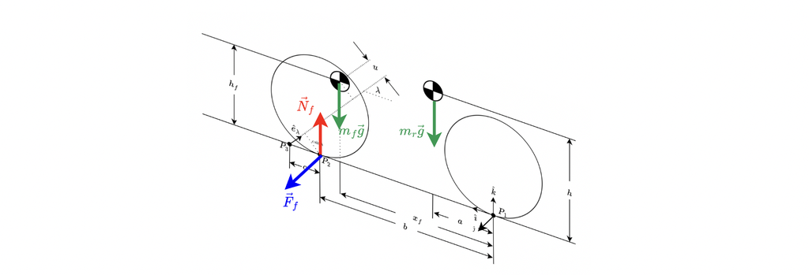

The gravitational forces may not technically be "tire contact forces," but they *will* produce torques about the roll ($\hat{\imath}$) axis when the bike is steered due to the displacement of the front and rear frames caused by the trail $c$. The kinematics notebook has a section that explains how steering the bike displaces the $\hat{\imath}$ axis by an angle $\Delta \psi = \frac{c\sin\lambda}{b}\delta$. We include these gravitational torques here because they are caused by steering-related displacement of the bike's rigid bodies relative to the front tire contact forces.

Our approach in this notebook with be to sum up all torques caused by gravitational and front tire contact forces to produce $\vec{\tau}_{TF}$, or the net "non-conservative" torque caused by contact force effects.

## Torque $\tau_{TF,\phi}$ about the roll axis caused by gravitational forces and displacement of the mass centers

The easiest contributions to $\vec{\tau}_{TF}$ to find are those caused by the two gravitational forces. The relevant figure from the kinematics notebook is reproduced below:

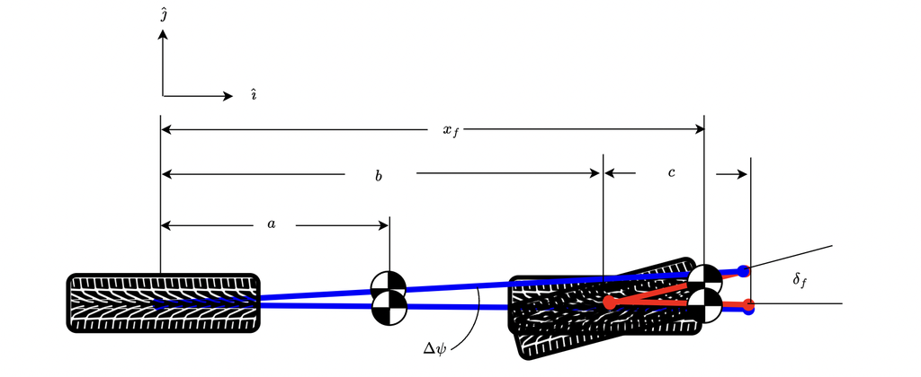

From the kinematics notebook, we know that the change in yaw angle of the motorcycle's rigid bodies resulting from steer angle $\delta_f=\delta\sin\lambda$ is $\Delta \psi = \frac{c\sin\lambda}{b}\delta$. This means that if we assume that $\Delta \psi$ is small such that $\sin\Delta \psi \approx \Delta \psi$, then the lateral displacement of the rear frame's center of mass from the line $P_1P_2$ is approximately $a\Delta\psi = \frac{ac\sin\lambda}{b}\delta$. Similarly , the lateral displacement of the front frame's center of mass from the line $P_1P_2$ is approximately $x_f\Delta\psi = \frac{x_fc\sin\lambda}{b}\delta$.

These lateral offsets are approximately perpendicular to the $\hat{\imath}$ direction, so the two gravitational contributions to the torque $\vec{\tau}_{TF}$ are simply the products of these perpendicular distances with their respective gravitational forces. Both torques are negative for a positive steering angle, and are in the $\hat{\imath}$ direction, as you can confirm using the right-hand rule:

\begin{equation} \vec{\tau}_{TF,g} = -\left(\frac{gm_rac\sin\lambda}{b}\delta + \frac{gm_fx_fc\sin\lambda}{b}\delta\right)\hat{\imath} = -\frac{g\left(m_ra+m_fx_f\right)c\sin\lambda}{b} \delta\hat{\imath} \end{equation}

You may be wondering why this torque is separate from the torque produced by gravity when the bike rolls. The reason is that the roll motion of the bike (and the steer motion, for the front frame) cause torques that are accounted for by the potential energy of the bike in the LaGrangian. The torque $\tau_{TF,g}$ is *independent* of how much potential energy the bike has, and is created by steer motion and gravity alone.

This torque was computed in the $\hat{\imath}$ direction, and it is the *only* torque produced by tire contact forces about the $\hat{\imath}$ direction, so we can use it to find the value of the scalar non-conservative torque $\tau_{TF,\phi}$ that we need for the fourth order derivation:

\begin{equation} \tau_{TF,\phi} = -\frac{g\left(m_ra+m_fx_f\right)c\sin\lambda}{b} \delta \end{equation}

## Torque $\tau_{TF,\delta}$ about the steering axis from front tire contact (friction and normal) forces

The front tire contact forces cannot produce torque about the $\hat{\imath}$ direction, since the tire contact point is coincident with that axis. However, it can still produce torque about the $\hat{k}$ (yaw) and $\hat{e}_\lambda = -\cos\lambda \hat{\imath} + \sin \lambda \hat{k}$ (steer) axes. To compute this torque, we can use the formal definition of torque about an axis of rotation, $\vec{T} =\vec{r}_\perp \times \vec{F}_c$, where $\vec{r}_\perp$ is the perpendicular distance from the application of the contact force $\vec{F}_c$ to the axis of rotation $\hat{e}_\lambda$. We will need to find both the total force applied and the perpendicular distance to continue.

### Front Tire Contact Forces

In this case, we have a total tire contact force $\vec{F}_c$ at point $P_2$ equal to:

\begin{equation} \vec{F}_c = F_f\hat{\jmath} + N_f \hat{k}\end{equation}

The normal force can be found by applying a static moment balance about $P_1$ in the $\hat{\jmath}$ direction, since the vehicle is assumed to undergo no significant pitch motion (rotation in $\hat{\jmath}$) without suspension and under the small roll and steer assumptions. Applying this static moment balance yields:

$$\sum \vec{T}\cdot \hat{\jmath} = 0 = g\left(m_ra+m_fx_f\right)-N_fb$$

This can be readily solved for $N_f$:

\begin{equation}N_f = \frac{g\left(m_ra+m_fx_f\right)}{b}\end{equation}

Unfortunately, $F_f$ cannot be readily determined-- it is a dynamic "constraint force," and it will need to be solved for in the derivation of the fourth order model. This is done here. We will leave $F_f$ as an unknown force for the remainder of this notebook.

### Perpendicular distance from front contact patch to steer axis

The perpendicular distance from the front tire contact patch to the steer axis can be found by taking a close look at the bike's coordinate system definition.

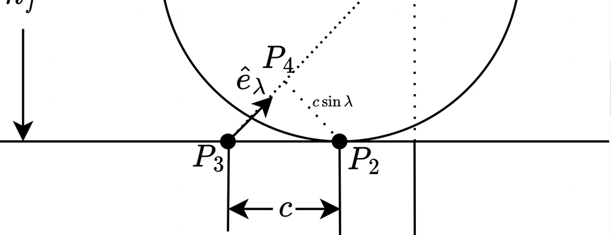

If we denote this vector $\vec{r}_\perp$, trigonometry tells us that its magnitude is $\left| \vec{r}_\perp \right| = c\sin\lambda$. However, its direction is less clear. We know the unit vector pointing from $P_2$ to $P_4$ will be perpendicular to the steer axis $\hat{e}_\lambda$, and *also* perpendicular to the $\hat{\jmath}$ unit vector attached to the front wheel. to find a unit vector perpendicular to two others, we can simply use the cross product! If we call our unknown unit vector $\hat{e}_{r\perp}$, we can compute:

$$\hat{e}_{r\perp} = \hat{\jmath}\times\left(-\cos\lambda \hat{\imath} + \sin\lambda \hat{k}\right) = \cos\lambda \hat{k} + \sin\lambda \hat{\imath}$$

This means that our vector $\vec{r}_\perp=\left| \vec{r}_\perp \right|\hat{e}_{r\perp}$ can be found:

\begin{equation} \vec{r}_\perp=c\sin\lambda \left(\cos\lambda \hat{k} + \sin\lambda \hat{\imath}\right) \end{equation}

which is valid *only when the bike is upright with no steer angle*.

### Influence of roll and steer on perpendicular distance between steer axis and front tire contact point

To find this unit vector, we first need to know how much the *front frame* of the motorcycle has rotated in the $\hat{\imath}$ direction. Of course, the biggest contributor to this angle is the roll angle $\phi$ of the front and rear frames, but some of the steer motion of the front frame also acts to change the front frame's total angle about the $\hat{\imath}$ axis.

In the kinematics notebook, we wrote the *steer axis* unit vector as $\hat{e}_{\lambda} = -\cos\lambda \hat{\imath} + \sin{\lambda}\hat{k}$, and used $\delta \hat{e}_\lambda \cdot \hat{k} = \delta_f$ to find the "ground steer" or "effective steer" angle as the portion of the steering motion of the front frame that is in the *yaw* direction.

We can use this same approach to help us find out how much the steering influences the front frame's "effective" or total roll angle about the $\hat{\imath}$ axis. To do this, we find $\hat{e}_\lambda\cdot\hat{\imath} = -cos\lambda$, which means that the portion of the steer angle vector $\vec{\delta}=\delta\hat{e}_\lambda$ that is in the "roll" direction is $-\delta\cos\lambda$.

Then, the total angle of the front frame about the $\hat{\imath}$ direction is:

\begin{equation} \phi_f = \phi-\delta\cos\lambda \end{equation}

To find the rotated version of our perpendicular distance vector $\vec{r}_\perp$, which we could call $\vec{r}_\perp^\prime = r_\perp \hat{e}_{r\perp}^\prime$, we can use a [rotation matrix](https://en.wikipedia.org/wiki/Rotation_matrix) to rotate the vector by $\phi_f$.

\begin{equation} \begin{aligned} \vec{r}_\perp^\prime &= c\sin\lambda \begin{bmatrix}1 & 0 & 0 \\ 0 & \cos\phi_f & -\sin\phi_f \\ 0 & \sin\phi_f & \cos\phi_f \end{bmatrix} \begin{bmatrix}\sin\lambda \\ 0 \\ \cos\lambda \end{bmatrix} \\ &= c\sin\lambda\left(\sin\lambda \hat{\imath} - \sin\phi_f\cos\lambda\hat{\jmath}+\cos\phi_f\cos\lambda\hat{k}\right) \end{aligned} \end{equation}

using the assumption of small $\phi_f$ such that $\sin\phi_f\approx\phi_f$ and $\cos\phi_f\approx 1$, we can write

\begin{equation} \vec{r}_\perp^\prime = c\sin\lambda \left( \sin\lambda \hat{\imath} - \phi_f\cos\lambda\hat{\jmath} + \cos\lambda\hat{k} \right) \end{equation}

### Final computation of the torque $\tau_{TF,\delta}$ in the steer axis direction

The torque $\vec{\tau}_{TF,c}$ results from forces that are coincident with the roll axis as defined. It can therefore only move the front frame, and only about the steering axis. So to determine the portion of this torque that can actually do work on the bike, we need to take the dot product $\tau_{TF,g}\cdot \hat{e}_{\lambda}^\prime$, which is the unit vector of the steer axis after the front frame has been rotated about the local $\hat{\imath}$ direction by the roll angle $\phi_f$. This will tell us what portion of the computed torque vector $\vec{\tau}_{TF,c}$ is able to do work on the steer axis.

To find $\hat{e}_{\lambda}^\prime$, we use a rotation matrix $R(\phi_f)$ about the $\hat{\imath}$ direction.

\begin{equation} \begin{aligned} \hat{e}_{\lambda}^\prime &= \underbrace{\begin{bmatrix}1& 0 & 0 \\ 0& \cos\phi& -\sin\phi_f \\ 0& \sin\phi_f& \cos\phi_f \end{bmatrix}}_{R(\phi_f)}\begin{bmatrix}-\cos\lambda \\ 0 \\ \sin\lambda \end{bmatrix}\\ &= -\cos\lambda \hat{\imath} - \sin\phi_f\sin\lambda \hat{\jmath} + \cos\phi_f\sin\lambda \hat{k} \end{aligned} \end{equation}

under the small $\phi_f$ assumption, we can write:

\begin{equation} \hat{e}_{\lambda}^\prime = -\cos\lambda \hat{\imath} - \phi_f\sin\lambda \hat{\jmath} + \sin\lambda \hat{k} \end{equation}

Then, we can take the dot product of our torque vector $\vec{\tau}_{TF,c}$ with $\hat{e}_{\lambda}^\prime$ to find $\tau_{TF,\delta}$

\begin{equation} \begin{aligned} \tau_{TF,\delta} &=\vec{\tau}_{TF,c} \cdot \hat{e}_{\lambda}^\prime \\ &= c\sin\lambda \left( -\left(N_f\phi_f\cos\lambda+F_f\cos\lambda\right)\hat{\imath} + N_f\sin\lambda \hat{\jmath} + F_f\sin\lambda\hat{k} \right)\cdot \left(-\cos\lambda \hat{\imath} - \phi_f\sin\lambda \hat{\jmath} + \sin\lambda \hat{k}\right) \\ &= c\sin\lambda\left(F_f\underbrace{\left(\sin^2\lambda + \cos^2\lambda\right)}_{1} + N_f\phi_f\underbrace{\left(\sin^2\lambda + \cos^2\lambda\right)}_{1} \right) \end{aligned} \end{equation}

Finally, simplifying and substituting Eqn 6 ($\phi_f = \phi - \delta \cos\lambda$) into Eqn 12 yields our final equation for $\tau_{TF,\delta}$.

\begin{equation} \tau_{TF,\delta} = c\sin\lambda\left( F_f + N_f\left(\phi - \delta\cos\lambda\right) \right) \end{equation}

## Torque $\tau_{TF,\psi}$ about the yaw axis from front tire friction.

Finally, the front tire frictional force, which acts purely in the $\hat{\jmath}$ direction, is perpendicularly situated by $b\hat{\imath}$ from the bike's coordinate origin. This means that it produces a torque on the bike's front and rear frames about the $\psi$ axis, which can be computed:

\begin{equation} \begin{aligned} \vec{\tau}_{TF,\psi} = \tau_{TF,\psi}\hat{k} &= b\hat{\imath}\times F_f\hat{\jmath}\\ &= bF_f\hat{k} \end{aligned} \end{equation}

And therefore the scalar value of the torque $\tau_{TF,\psi}$ needed for the fourth order derivation can be written:

\begin{equation} \tau_{TF,\psi} = bF_f \end{equation}

Note that there is no corresponding torque written for the rear tire-- this is of course because the rear tire contact point is the vehicle's coordinate system origin! This means no force applied at this point could create a torque.